# Marginalizing shocks: A step back to stay on track

*Cover that shocks which I ought not to see.*

# 1 Model reparameterization

We marginalize the shocks in the mixture model! Going from:

```stan
# Non-shocky
target += normal_lpdf(y[n] | mu[n] + delta_sck[n], sigma)
target += normal_lpdf(delta_sck[n] | 0, inner_tau_sck)

# Shocky
target += normal_lpdf(y[n] | mu[n] + delta_sck[n], sigma)
target += normal_lpdf(delta_sck[n] | 0, outer_tau_sck)
```

to a log-likelihood where shocks are marginalized out:

```stan
# Non-shocky
target += normal_lpdf(y[n] | mu[n], eta)

# Shocky
target += normal_lpdf( y[n] | mu[n], eta * sqrt{1 + nu / eta^2})
```

where:
$$\eta = \sqrt{ \sigma^2 + {\tau_\text{inner}^\text{shock}}^2 }$$
$$\nu = {\tau_\text{outer}^\text{shock}}^2-{\tau_\text{inner}^\text{shock}}^2$$

**Expand to see he new model block**

```r
writeLines(
  readLines(file.path(wd, 'model', 'stan',
                      'model9_marginalshocks.stan'))[230:315])
```

```
model {

  alpha ~ normal(0, 0.69); // 0.2 mm <~ exp(alpha) * 1 mm <~ 5 mm

  beta_gdd ~ normal(0, log(1.8) / 2.57); // -log(1.8) <~ beta_gsl <~ log(1.8)
  beta_sm ~ normal(0, log(1.8) / 2.57); // -log(1.8) <~ beta_gsl <~ log(1.8)
  beta_vpd ~ normal(0, log(1.8) / 2.57); // -log(1.8) <~ beta_gsl <~ log(1.8)

  rho_sp ~ lognormal(2.65, 0.135); // 10 <~ rho <~ 20

  gamma_sp ~ normal(0, log(10) / 2.57); // 0 <~ gamma <~ log(10)

  for (s in 1:N_stands)
    f_tilde_sh[s] ~ normal(0, 1);
  rho_sh ~ lognormal(1.7, 0.26);       // 3 <~ rho_sh <~ 10
  gamma_sh ~ normal(0, log(3) / 2.57); // 0 <~ gamma_sh <~ log(3)

  eta ~ gamma(6, 43.5);
  nu ~ gamma(0.5, 0.033);
  phi_sck ~ beta(2, 20);
  omega_conc_sck ~ beta(230, 14); // 0.9 <~ omega_conc_sck <~ 0.97 (most trees, but not ALL trees)
  omega_nonconc_sck ~ beta(1, 20); // 0 <~ omega_conc_sck <~ 0.15 (should be rare, but... who knows?)

  vector[N] mu;
  for (t in 1:N_trees) {
    array[N_years[t]] int tree_idxs
    = linspaced_int_array(N_years[t],
                          tree_start_idxs[t],
                          tree_end_idxs[t]);

    array[N_years[t]] int all_years_idxs_tree = all_years_idxs[tree_idxs];
    array[N_years[t]] real years_tree = years[tree_idxs];

    int stand_idx = stand_idxs[t];
    int species_idx = species_idxs[t];

    vector[N_years[t]] gdd_obs_tree = gdd_obs[tree_idxs];
    vector[N_years[t]] sm_obs_tree = sm_obs[tree_idxs];
    vector[N_years[t]] vpd_obs_tree = vpd_obs[tree_idxs];

```

[output cut: 30 more lines]

```
        log_p1[ys] += log_mix(omega_conc_sck,
                          normal_lpdf(log_rw_obs[tree_idxs[y]] | mu[tree_idxs[y]]
                          + f[tree_idxs[y]], eta * sqrt(1 + nu / eta^2)),
                          normal_lpdf(log_rw_obs[tree_idxs[y]] | mu[tree_idxs[y]]
                          + f[tree_idxs[y]], eta));

      }
    }

    for(y in 1:N_stand_years[s]) {
      target += log_mix(phi_sck[s], log_p1[y], log_p0[y]);
    }
  }

}
```

# 2 Recover the shocks afterwards

Our large shocks are likely tied to interesting ecological stuff… But by marginalizing them, we don’t have inferences on them anymore.
It’s easy to recover the shock state, but what about the shock amplitude?
If I assume that ${\tau_\text{inner}^\text{shock}} = 0$, I can reconstruct the large shocks using the normal-normal conjugancy:
$$\delta_\text{shock}(k) ~|~ y_k \sim \text{normal} \left( ({\tau_\text{outer}^\text{shock}}^2 / ({\tau_\text{outer}^\text{shock}}^2 + \sigma^2)) \times y_k ~,~ \sqrt{({\tau_\text{outer}^\text{shock}}^2 \times \sigma^2) / ({\tau_\text{outer}^\text{shock}}^2 + \sigma^2)}\right)$$

# 3 Time to deal with those zeros!

Before digging too much on the shocks, I should first consider to deal with the missing rings.  
We have domain expertise to say that zeros are a signature of extreme tree stress and very low growth. These missing rings correspond to observations that are below the measurement precision, which should be around $1\mathrm{e}{-3} ~\text{mm}$! We should thus consider that the probability of having a missing ring corresponds to the probability of getting values from `-Inf` to some threshold `epsilon` (which can be fixed, or a parameter to infer). The pseudo-code would be:

```stan
if(rw_obs[tree_idxs[y]] >= epsilon){
  target += normal_lpdf(log(rw_obs[tree_idxs[y]]) | mu[n], sqrt(outer_tau2_aux+sigma^2))
}else{
  target += normal_lcdf(log(epsilon)) | mu[n], sqrt(outer_tau2_aux+sigma^2))
}
```

**Warning**

Here I used the condition `rw_obs[tree_idxs[y]] >= epsilon`, because `epsilon` is the “last” observed value before zero. I do have a minor concern, though: `log(epsilon)` is also included in the normal_lcdf integral… Is it a big issue?

I modified the Stan code to include this censoring.

**Expand to see a portion of the new model block**

```r
writeLines(
  readLines(file.path(wd, 'model', 'stan',
                      'model9_marginalshocks_zerotauinner_censoring_onlyconcordant.stan'))[310:326])
```

```
        if(rw_obs[tree_idxs[y]] > epsilon){
          log_p0[ys] += normal_lpdf(log(rw_obs[tree_idxs[y]]) | mu[tree_idxs[y]]
                          + f[tree_idxs[y]], sigma);
          log_p1[ys] += log_mix(omega_conc_sck,
                          normal_lpdf(log(rw_obs[tree_idxs[y]]) | mu[tree_idxs[y]]
                          + f[tree_idxs[y]], sqrt(outer_tau_sck^2 + sigma^2)),
                          normal_lpdf(log(rw_obs[tree_idxs[y]]) | mu[tree_idxs[y]]
                          + f[tree_idxs[y]], sigma));
        }else{
          log_p0[ys] += normal_lcdf(log(epsilon) | mu[tree_idxs[y]]
                          + f[tree_idxs[y]], sigma);
          log_p1[ys] += log_mix(omega_conc_sck,
                          normal_lcdf(log(epsilon) | mu[tree_idxs[y]]
                          + f[tree_idxs[y]], sqrt(outer_tau_sck^2 + sigma^2)),
                          normal_lcdf(log(epsilon) | mu[tree_idxs[y]]
                          + f[tree_idxs[y]], sigma));
        }
```

But I am less sure on how to handle this in the `generated quantities` block.  
For now, when the observation $y$ is below the threshold $\epsilon$, I sample a $\log(y)$ in a truncated normal distribution (between $-\infty$ and $\log(\epsilon)$).

**Expand to see a portion of the new generated quantities block**

```r
writeLines(
  readLines(file.path(wd, 'model', 'stan',
                      'model9_marginalshocks_zerotauinner_censoring_onlyconcordant.stan'))[394:411])
```

```
      if(sck_state[tree_idxs[y]] == 0){
        log_rw_pred[tree_idxs[y]] = normal_rng(mu[y] + f[tree_idxs[y]], sigma);
      }else if(rw_obs[tree_idxs[y]] > epsilon){
        // we can reconstruct shock posterior using the normal-normal conjugancy
        real residual = log(rw_obs[tree_idxs[y]]) - mu[y] - f[tree_idxs[y]];
        real conjugate_mean = (outer_tau_sck^2 / (outer_tau_sck^2 + sigma^2)) * residual;
        real conjugate_sd   = sqrt((outer_tau_sck^2 * sigma^2) / (outer_tau_sck^2 + sigma^2));
        delta_sck[tree_idxs[y]] = normal_rng(conjugate_mean, conjugate_sd);
        log_rw_pred[tree_idxs[y]] = normal_rng(mu[y] + f[tree_idxs[y]] + delta_sck[tree_idxs[y]], sigma);
      }else{
        // sample from a truncated normal distribution? between -inf and log(epsilon)
        real log_y = normal_ub_rng(mu[y] + f[tree_idxs[y]], sqrt(outer_tau_sck^2 + sigma^2), log(epsilon));
        real residual = log_y - mu[y] - f[tree_idxs[y]];
        real conjugate_mean = (outer_tau_sck^2 / (outer_tau_sck^2 + sigma^2)) * residual;
        real conjugate_sd   = sqrt((outer_tau_sck^2 * sigma^2) / (outer_tau_sck^2 + sigma^2));
        delta_sck[tree_idxs[y]] = normal_rng(conjugate_mean, conjugate_sd);
        log_rw_pred[tree_idxs[y]] = normal_rng(mu[y] + f[tree_idxs[y]] + delta_sck[tree_idxs[y]], sigma);
      }
```

I defined the truncated normal sampling function with the help of Stan manual.  
I add a condition to deal with `p_ub = 0`, when the probability that a sample from `normal(mu, sigma)` is below `ub` is zero. In this case, I consider that the entire density collapses to a single point, `ub` (i.e. $\log(\epsilon)$).

```r
writeLines(
  readLines(file.path(wd, 'model', 'stan',
                      'model9_marginalshocks_zerotauinner_censoring_onlyconcordant.stan'))[57:67])
```

```
  // see truncated-random-number-generation on Stan's user guide
  real normal_ub_rng(real mu, real sigma, real ub) {
    real p_ub = normal_cdf(ub, mu, sigma);
    // deal with the limit case of the truncated normal
    // to avoid error: "Exception: uniform_rng: Upper bound parameter is 0"
    if (p_ub == 0)
      return ub;
    real u = uniform_rng(0, p_ub);
    real y = mu + sigma * inv_Phi(u);
    return y;
  }
```

Currently I just set: `real epsilon = 1e-3;`. But we could fit this parameter later.

# 4 A first fit on two stands

Here, we consider that:

- we have a normal population model for the shocks, with ${\tau_\text{inner}^\text{shock}} = 0$ (see above)
- $\phi_\text{shock}$, the stand-level shock probability, varies across stands (heterogeneous)
- $\omega_\text{shock}^\text{concordant}$, the tree-level shock probability given the stand is shocking, does not vary across stands (homogeneous)
- $\omega_\text{shock}^\text{non-concordant} = 0$ (no tree-level shock without a stand-level shock)

```r
data <- readRDS(file = file.path(wd, 'output', 'model', 'data_15nov2025_az592_az628.rds'))
data$rw_obs <- ifelse(data$log_rw_obs == log(1e-4), 0, exp(data$log_rw_obs))

if(FALSE){
  fit <- stan(file=file.path(wd, 'model', 'stan', 'model9_marginalshocks_zerotauinner_censoring.stan'),
            data=data, seed=5838293, chains = 4,
            warmup=1000, iter=2024, refresh=10)
  saveRDS(fit, file.path(wd, 'model/shocks/output/marginal', 'fit_normal_censoring.rds'))
}else{
  fit <- readRDS(file.path(wd, 'model/shocks/output/marginal', 'fit_normal_censoring.rds'))
}
```

Woaa! A flood of tree depth warnings.

```r
diagnostics <- util$extract_hmc_diagnostics(fit)
util$check_all_hmc_diagnostics(diagnostics)
```

```
           saturated the maximum treedepth of 10.

           saturated the maximum treedepth of 10.

           saturated the maximum treedepth of 10.

           saturated the maximum treedepth of 10.

  Numerical trajectories that saturate the maximum treedepth have
terminated prematurely.  Increasing max_depth above 10 should result in
more expensive, but more efficient, Hamiltonian transitions.
```

```r
samples <- util$extract_expectand_vals(fit)
base_samples <- util$filter_expectands(samples,
                                       c('alpha',
                                         'beta_gdd', 'beta_sm', 'beta_vpd',
                                         'rho_sh', 'gamma_sh',
                                         'rho_sp', 'gamma_sp',
                                         'sigma',
                                         'phi_sck', 'omega_conc_sck'),
                                       check_arrays = TRUE)
util$check_all_expectand_diagnostics(base_samples)
```

```
rho_sp[1]:


Small empirical effective sample sizes result in imprecise Markov chain
Monte Carlo estimators.
```

Let’s do some retrodictive checks! Let’s look at 4 trees on the first stand:

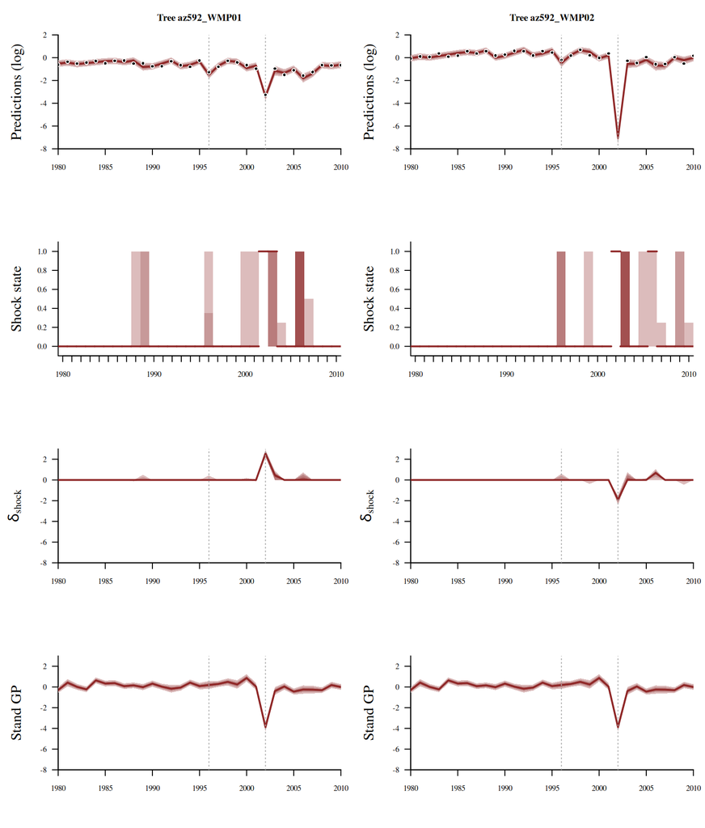

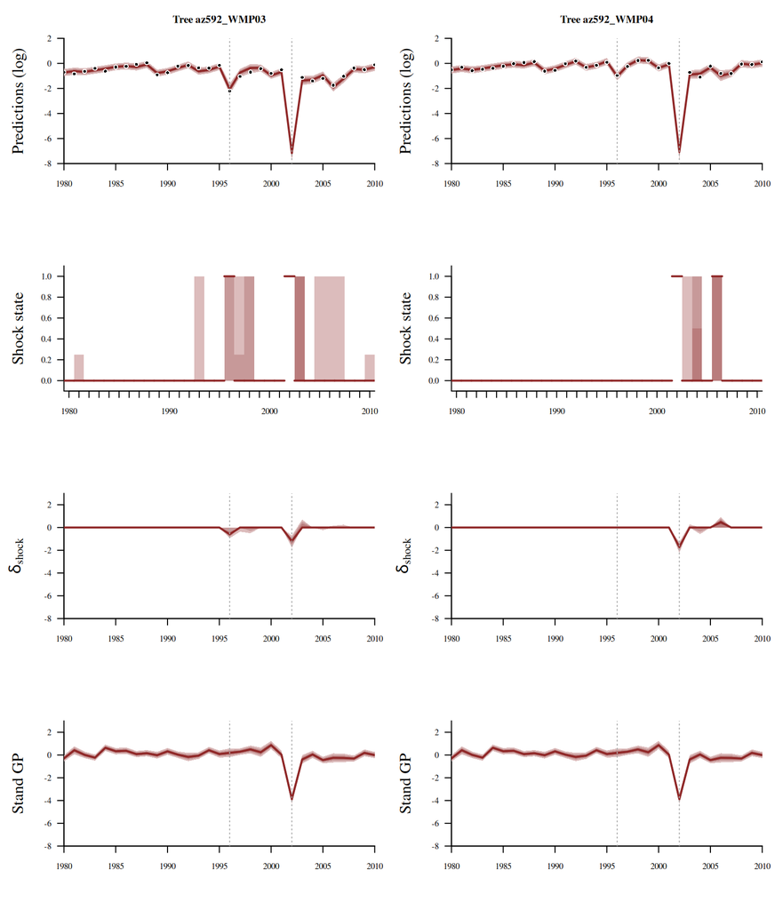

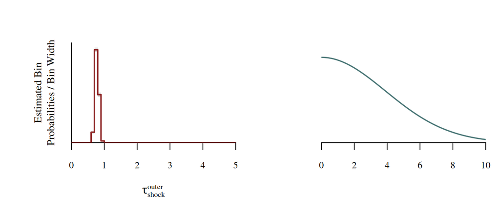

# 5 Considering a heterogeneous $\omega_\text{shock}^\text{concordant}$

We add some flexibility to our model! Now, we consider that:

- $\phi_\text{shock}$ and $\omega_\text{shock}^\text{concordant}$ varies across stands (heterogeneous)

```r
if(FALSE){
  fit2 <- stan(file=file.path(wd, 'model', 'stan', 'model9_marginalshocks_zerotauinner_censoring_onlyconcordant_heterogeneous.stan'),
              data=data, seed=5838293, chains = 4,
              warmup=1000, iter=2024, refresh=10)
  saveRDS(fit2, file.path(wd, 'model/shocks/output/marginal', 'fit_normal_censoring_heterogeneous.rds'))
}else{
  fit2 <- readRDS(file.path(wd, 'model/shocks/output/marginal', 'fit_normal_censoring_heterogeneous.rds'))
}
```

Still a good amount of warnings! But only for one chain now.

```r
diagnostics <- util$extract_hmc_diagnostics(fit2)
util$check_all_hmc_diagnostics(diagnostics)
```

```
           saturated the maximum treedepth of 10.

  Numerical trajectories that saturate the maximum treedepth have
terminated prematurely.  Increasing max_depth above 10 should result in
more expensive, but more efficient, Hamiltonian transitions.
```

However the parameter-level warnings are more concerning.

```r
samples2 <- util$extract_expectand_vals(fit2)
base_samples <- util$filter_expectands(samples2,
                                       c('alpha',
                                         'beta_gdd', 'beta_sm', 'beta_vpd',
                                         'rho_sh', 'gamma_sh',
                                         'rho_sp', 'gamma_sp',
                                         'sigma',
                                         'phi_sck', 'omega_conc_sck'),
                                       check_arrays = TRUE)
util$check_all_expectand_diagnostics(base_samples)
```

```
beta_gdd[1]:
  Split hat{R} (1.191) exceeds 1.1.

beta_sm[1]:
  Split hat{R} (1.445) exceeds 1.1.

gamma_sh:
  Split hat{R} (3.616) exceeds 1.1.

rho_sp[1]:
  Split hat{R} (1.313) exceeds 1.1.

sigma:
  Split hat{R} (5.155) exceeds 1.1.

phi_sck[1]:
  Split hat{R} (1.314) exceeds 1.1.

phi_sck[2]:
  Split hat{R} (1.849) exceeds 1.1.

omega_conc_sck[1]:
  Split hat{R} (1.218) exceeds 1.1.

omega_conc_sck[2]:
  Split hat{R} (1.522) exceeds 1.1.


Split Rhat larger than 1.1 suggests that at least one of the Markov
chains has not reached an equilibrium.

Small empirical effective sample sizes result in imprecise Markov chain
Monte Carlo estimators.
```

We can look at the pair plot between $\sigma$ and $\gamma_\text{short}$:

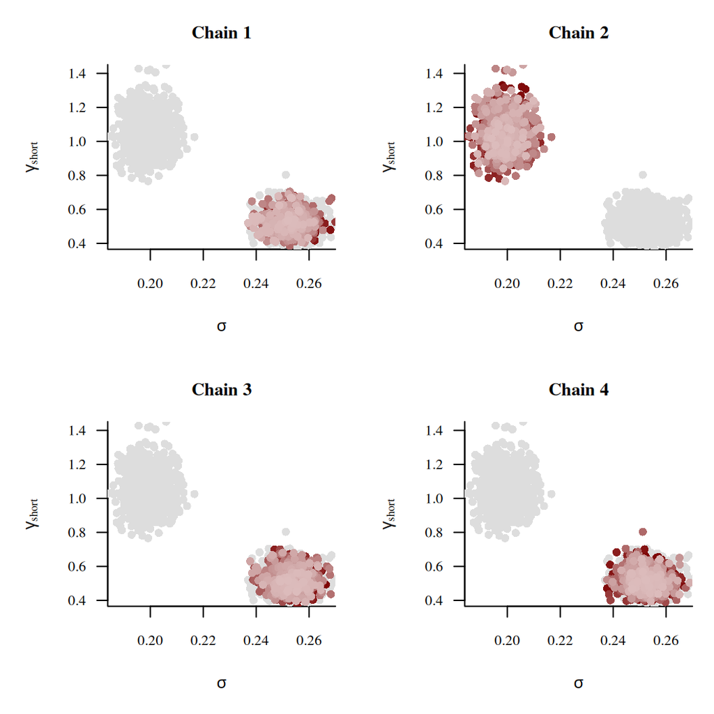

Looking at the two stand GPs reveals the two modes for $\gamma_\text{short}$… at least on stand 1.

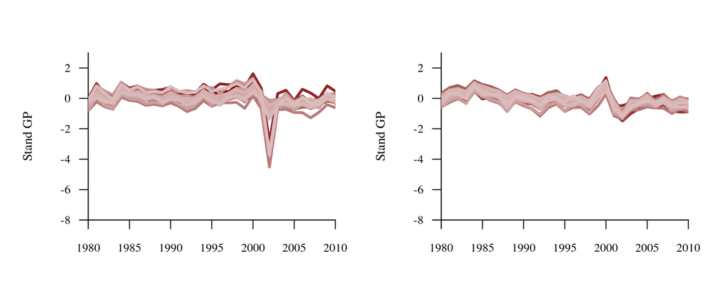

If we look at the pair plot between $\phi_\text{shock}$ and $\omega_\text{shock}^\text{concordant}$, for stand 1:

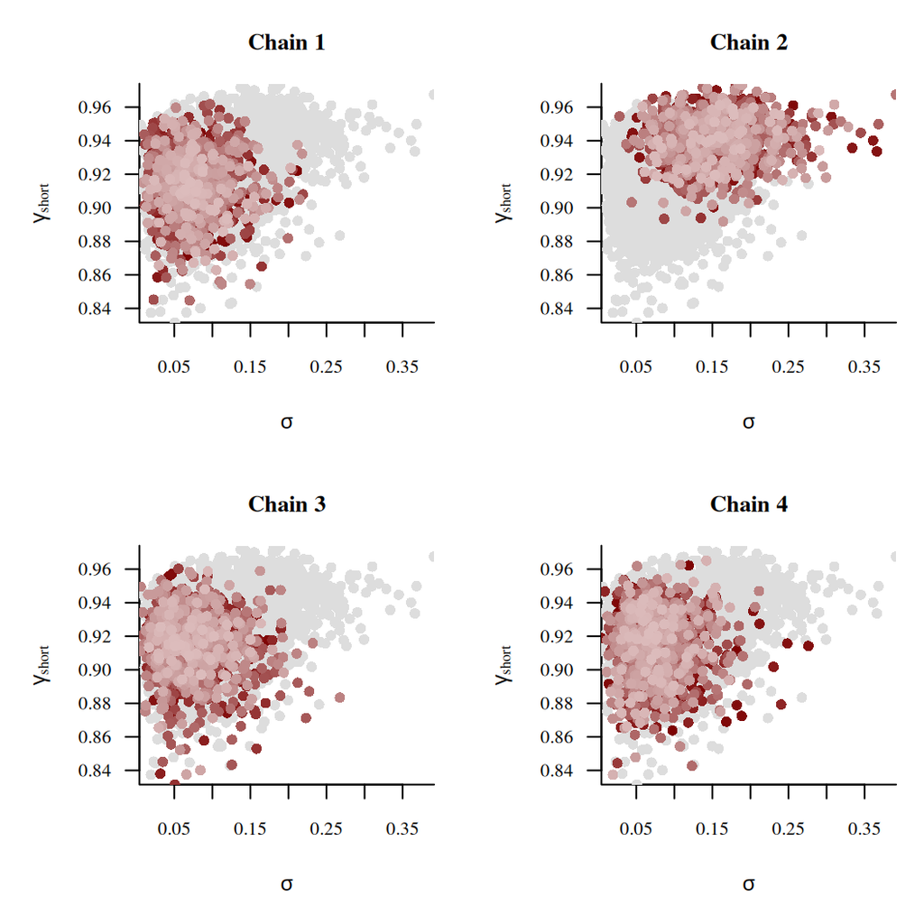

And stand 2:

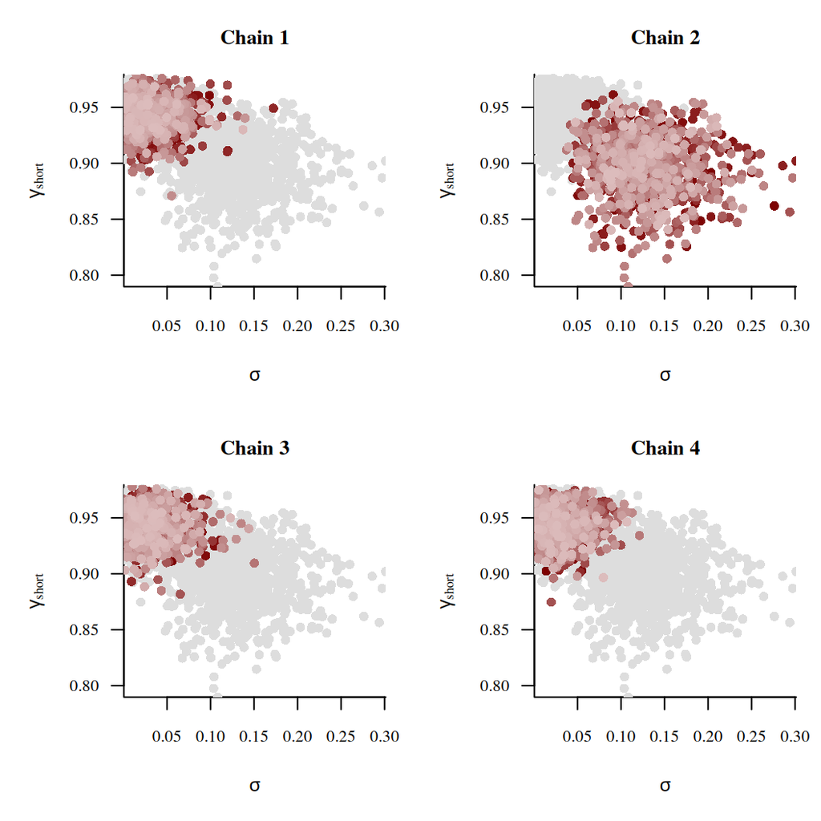

However, the retrodictive check on the trees of stand 1 seems to indicate that we are on a good path!

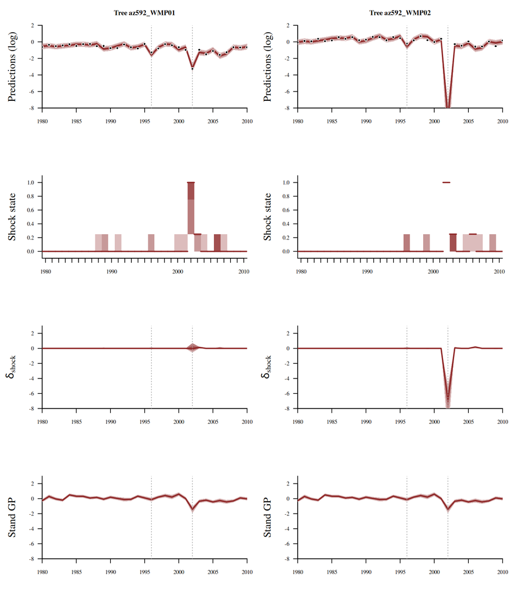

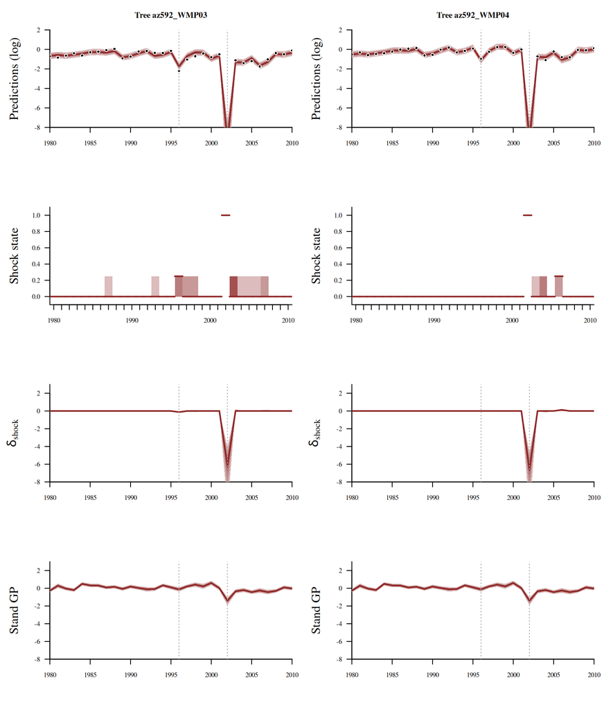

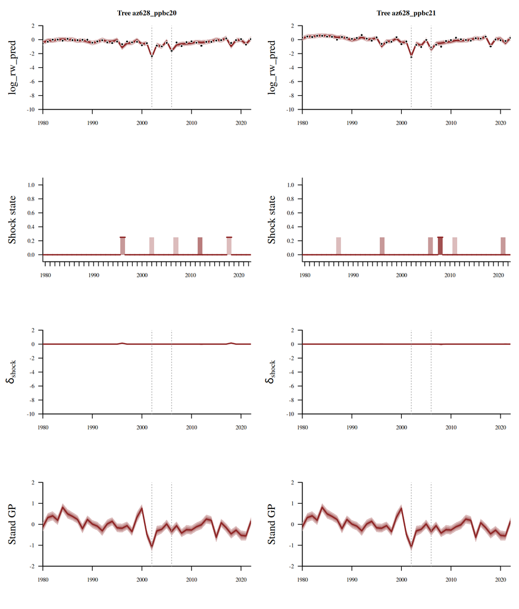

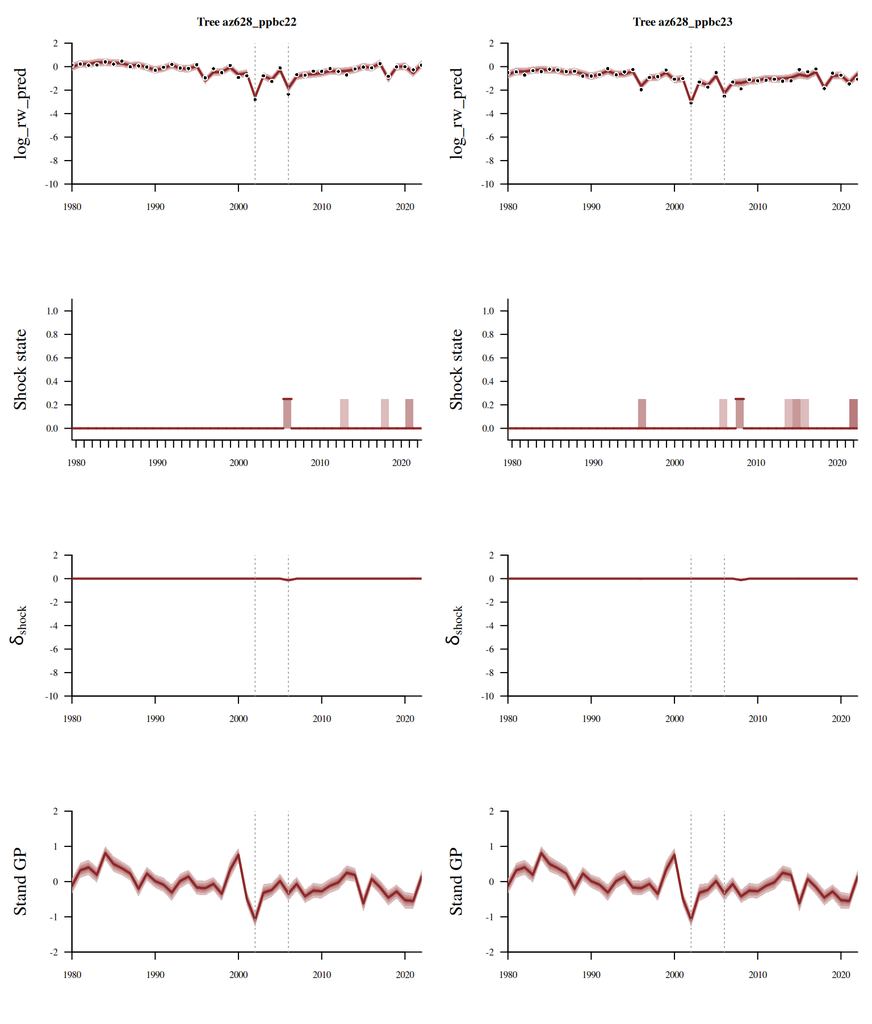

```r
par(mfcol = c(4,2))
for(t in 41:44){
  idxs_t <- data$tree_start_idxs[t]:data$tree_end_idxs[t]
  names <- sapply(idxs_t,
                  function(x) paste0('log_rw_pred[', x, ']'))
  util$plot_conn_pushforward_quantiles(samples2, names, data$years[idxs_t],
                                       xlab="", ylab='log_rw_pred', main = paste0('Tree ', data$uniq_tree_ids[t]),
                                       display_ylim=c(-10, 2), display_xlim = c(1980, 2022))
  points(data$years[idxs_t], data$log_rw_obs[idxs_t], pch=16, cex=1, col="white")
  points(data$years[idxs_t], data$log_rw_obs[idxs_t], pch=16, cex=0.6, col="black")
  abline(v =  c(2002,2006), lty = 3, col="darkgrey")

  names <- sapply(idxs_t,
                  function(x) paste0('sck_state[', x, ']'))
  ticks <- c(unlist(lapply(seq(1980, 2010,10), function(x) c(x, rep(NA, 9)))), '2020',NA,NA)
  util$plot_disc_pushforward_quantiles(samples2, names, data$years[idxs_t],
                                       xlab="", ylab='Shock state',
                                       display_ylim=c(-0.1, 1.1),
                                       xticklabs =  ticks)
  abline(v =  c(2002,2006), lty = 3, col="darkgrey")

  names <- sapply(idxs_t,
                  function(x) paste0('delta_sck[', x, ']'))
  util$plot_conn_pushforward_quantiles(samples2, names, data$years[idxs_t],
                                       xlab="", ylab=expression(delta[shock]),
                                       display_ylim=c(-10, 2), display_xlim = c(1980, 2022))
  abline(v =  c(2002,2006), lty = 3, col="darkgrey")

  names <- sapply(1:data$N_all_years,
                  function(x) paste0('f_sh[', data$stand_idxs[t],',',x, ']'))
  util$plot_conn_pushforward_quantiles(samples2, names, data$all_years,
                                       xlab="", ylab='Stand GP',
                                       display_ylim=c(-2, 2), display_xlim = c(1980, 2022))
  abline(v = c(2002,2006), lty = 3, col="darkgrey")
}
```